# Contrasts

Witold Wolski

19 May 2017

## Contrast Treatment

```r
# setting seed so that numerical results stay stable
set.seed(25)
# let's imagine an experiment which measure plant biomass based on various
# levels of nutrient added to the medium first case one treatments three
# levels
f <- gl(n = 3, k = 20, labels = c("control", "low", "high"))
# with treatments contrasts (default)
mat <- model.matrix(~f, data = data.frame(f = f))
# this tell us which contrast has been used to generate the model matrix
attr(mat, "contrasts")
```

```
## $f
## [1] "contr.treatment"
```

```r
# simulate some ys
beta <- c(12, 3, 6)  #these are the simulated regression coefficient
y <- rnorm(n = 60, mean = mat %*% beta, sd = 2)
m <- lm(y ~ f)
summary(m)
```

```
##
## Call:
## lm(formula = y ~ f)
##
## Residuals:
##     Min      1Q  Median      3Q     Max
## -4.3505 -1.6114  0.1608  1.1615  5.2010
##
## Coefficients:
##             Estimate Std. Error t value Pr(>|t|)
## (Intercept)  11.4976     0.4629  24.840  < 2e-16 ***
## flow          3.0370     0.6546   4.639 2.09e-05 ***
## fhigh         6.1630     0.6546   9.415 3.27e-13 ***
## ---
## Signif. codes:  0 '***' 0.001 '**' 0.01 '*' 0.05 '.' 0.1 ' ' 1
##
## Residual standard error: 2.07 on 57 degrees of freedom
## Multiple R-squared:  0.6086, Adjusted R-squared:  0.5949
## F-statistic: 44.32 on 2 and 57 DF,  p-value: 2.446e-12
```

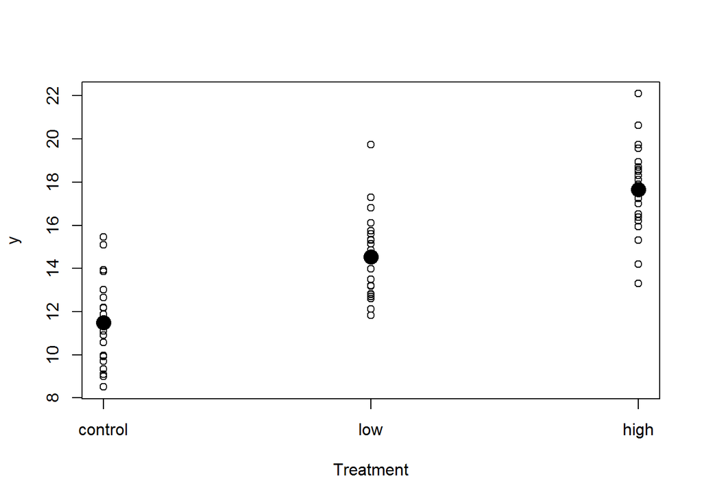

```r
# plot the results
plot(y ~ rep(1:3, each = 20), xaxt = "n", xlab = "Treatment")
axis(1, at = c(1, 2, 3), labels = levels(f))
points(c(1, 2, 3), c(coef(m)[1], coef(m)[2:3] + coef(m)[1]), pch = 16, cex = 2)
```

This is by default, now let’s turn to other contrasts options:

## Helmert

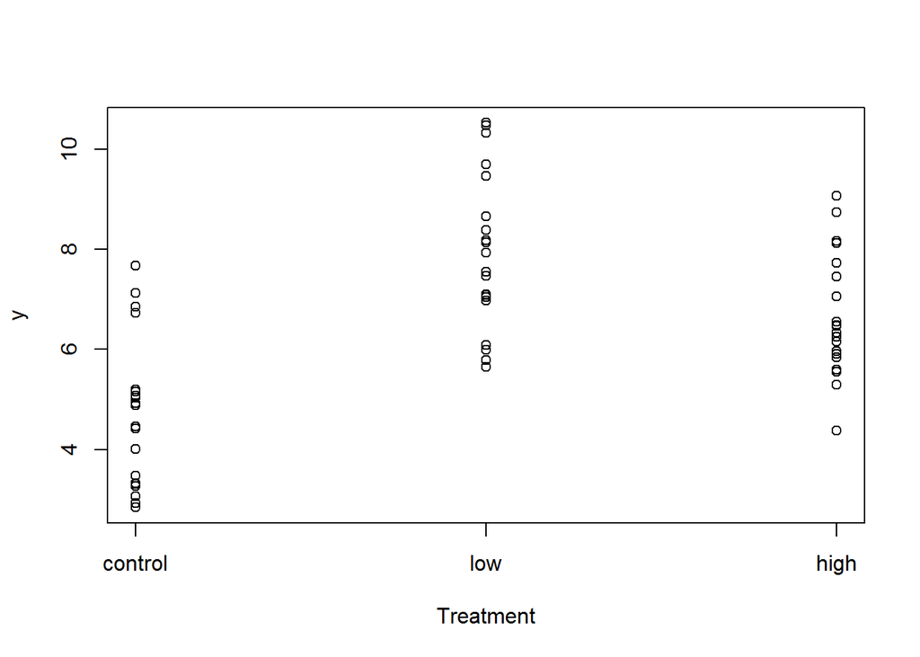

```r
# simulate the ys
beta <- c(5, 3, 2)
y <- rnorm(n = 60, mean = mat %*% beta, sd = 1.5)
plot(y ~ rep(1:3, each = 20), xaxt = "n", xlab = "Treatment")
axis(1, at = c(1, 2, 3), labels = levels(f))
```

```r
# model
m <- lm(y ~ f, contrasts = list(f = "contr.helmert"))  #there we tell the model to use helmert contrast to build the model
summary(m)
```

```
##
## Call:
## lm(formula = y ~ f, contrasts = list(f = "contr.helmert"))
##
## Residuals:
##     Min      1Q  Median      3Q     Max
## -2.2809 -0.9734 -0.2021  0.7524  2.9857
##
## Coefficients:
##             Estimate Std. Error t value Pr(>|t|)
## (Intercept)   6.4229     0.1835  35.000  < 2e-16 ***
## f1            1.6160     0.2248   7.190 1.53e-09 ***
## f2            0.1158     0.1298   0.892    0.376
## ---
## Signif. codes:  0 '***' 0.001 '**' 0.01 '*' 0.05 '.' 0.1 ' ' 1
##
## Residual standard error: 1.421 on 57 degrees of freedom
## Multiple R-squared:  0.4794, Adjusted R-squared:  0.4612
## F-statistic: 26.25 on 2 and 57 DF,  p-value: 8.308e-09
```

## effect (or deviation) coding

```r
# now with sum contrasts, let's spice up a little bit and introduce an
# interaction with a continuous variables
x <- runif(60, -2, 2)
levels(f) <- c("North", "South", "Center")  #let's make different level which cannot easily be given an order or a baseline
mat <- model.matrix(~x * f, data = data.frame(f = f), contrasts.arg = list(f = "contr.sum"))
attr(mat, "contrasts")
```

```
## $f
## [1] "contr.sum"
```

```r
# simulate the ys
beta <- c(5, -2, 3, 2, 1, -4)
y <- rnorm(n = 60, mean = mat %*% beta, sd = 1.5)

# model
m <- lm(y ~ x * f, contrasts = list(f = "contr.sum"))
summary(m)
```

```
##
## Call:
## lm(formula = y ~ x * f, contrasts = list(f = "contr.sum"))
##
## Residuals:
##     Min      1Q  Median      3Q     Max
## -3.2707 -1.0206 -0.1645  0.8672  3.9142
##
## Coefficients:
##             Estimate Std. Error t value Pr(>|t|)
## (Intercept)   5.0567     0.2071  24.422  < 2e-16 ***
## x            -1.8695     0.1846 -10.127 4.37e-14 ***
## f1            2.6992     0.2948   9.155 1.41e-12 ***
## f2            2.3507     0.2927   8.032 8.77e-11 ***
## x:f1          0.9541     0.2642   3.611 0.000669 ***
## x:f2         -4.2694     0.2682 -15.921  < 2e-16 ***
## ---
## Signif. codes:  0 '***' 0.001 '**' 0.01 '*' 0.05 '.' 0.1 ' ' 1
##
## Residual standard error: 1.579 on 54 degrees of freedom
## Multiple R-squared:  0.9216, Adjusted R-squared:  0.9143
## F-statistic: 126.9 on 5 and 54 DF,  p-value: < 2.2e-16
```

This type of contrasts is useful when there is no natural way to set a baseline or an ordering in the different levels of the variables. I changed the name of the level to illustrate what I mean by this, let’s imagine in this context that we had sampled our plant in three different localities, it is hard to determine in this context what should be the baseline, the deviation coding is a nice way to model these type of data. The intercept in this context is the overall mean across the levels (as in the helmert contrasts), so overall the plant biomass was 5.05. The second one the the average slope between the biomass and the x variable, if we increase x by one the plant biomass decrease by 1.87 across the geographical gradient. f1 is the difference between the overall mean and the mean in the north locality, similarly f2 is the difference between the overall mean and the south locality. To get the estimated average value at the center locality we have to do:

```r
coef(m)[1] - coef(m)[3] - coef(m)[4]
```

```
## (Intercept)
## 0.006780421
```

The interaction coefficient are the deviation of the slope within a group from the overall slope, therefore in the north if we increase x by 1, we decrease the biomass by -1.87+0.95= -0.92, similarly the slope in the south is -1.87+(-4.27)= -6.14 and in the center: -1.87-(+0.95)-(-4.27) = +1.45. Around each of these coefficient we have some assessment of the significance of the difference between the overall mean and the various groups. So far I could not find a way to assess the significance of the difference between the overall mean and the last group …

Let’s do a nice figure of this:

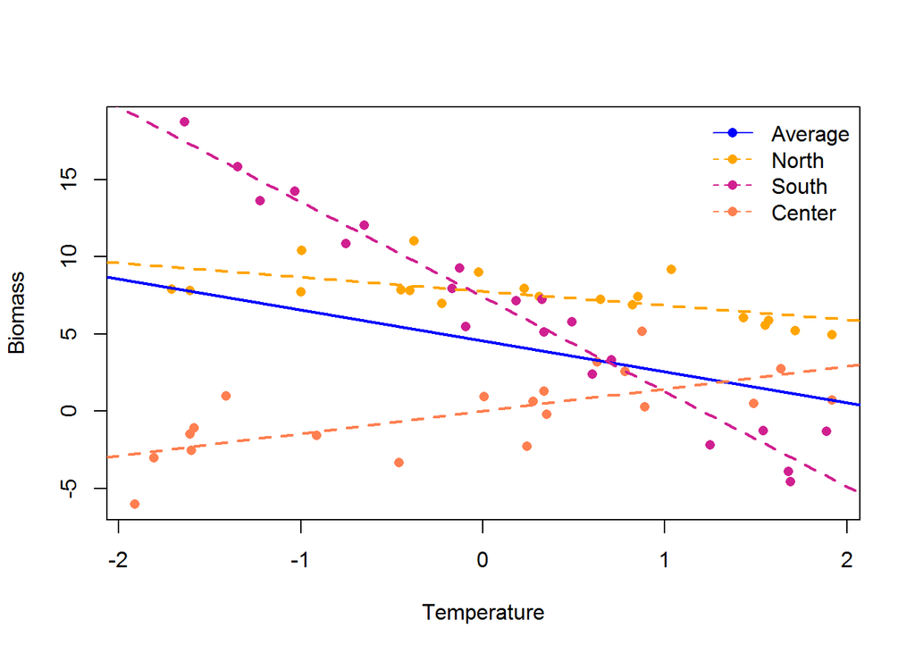

```r
# a nice plot
plot(y ~ x, xlab = "Temperature", ylab = "Biomass",
     pch = 16, col = rep(c("orange", "violetred", "coral"), each = 20))
abline(a = 4.55, b = -2, lwd = 2, lty = 1, col = "blue")
abline(a = coef(m)[1] + coef(m)[3], b = coef(m)[2] + coef(m)[5], lwd = 2, lty = 2,
       col = "orange")
abline(a = coef(m)[1] + coef(m)[4], b = coef(m)[2] + coef(m)[6], lwd = 2, lty = 2,
       col = "violetred")
abline(a = coef(m)[1] - coef(m)[3] - coef(m)[4], b = coef(m)[2] - coef(m)[5] -
         coef(m)[6], lwd = 2, lty = 2, col = "coral")
legend("topright", legend = c("Average", "North", "South", "Center"),
       col = c("blue","orange", "violetred", "coral"), pch = 16, lty = c(1, 2, 2, 2), bty = "n")
```